# Білет No 20

Юрій Харченко

12/21/2020

## Узагальнені моделі регресії

Узагальнені лінійні моделі (Generalized Linear Models) - універсальний метод побудови регресійних моделей, який дозволяє враховувати взаємодію між факторами, вид розподілу залежної змінної і припущення щодо характеру регресійної залежності.

Метод може бути використаний у всіх областях застосування прикладної статистики - медицина, екологія, демографія, сільське господарство, геологія, археологія, психологія, соціологія тощо. Однак найбільше застосування узагальнені лінійні моделі отримали в страхуванні.

GLM є добре розробленим і простим для розуміння способом побудови моделей. Завдяки комп’ютерним технологіям, побудова GLM не вимагає від дослідника глибинних знань в математичній статистиці. Тому все більша кількість користувачів застосовують цей метод для побудови адекватних моделей.

## Додати Seatbelts в робоче середовище R та провести його аналіз

```r
library(tidyverse)
library(DT)
library(psych)
library(car)
```

### Завантажуємо та дивимось

```r
data(Seatbelts)
datatable(Seatbelts)
```

| DriversKilled | drivers | front | rear | kms | PetrolPrice | VanKilled | law |
| --- | --- | --- | --- | --- | --- | --- | --- |
| 107 | 1687 | 867 | 269 | 9059 | 0.102971811805368 | 12 | 0 |
| 97 | 1508 | 825 | 265 | 7685 | 0.102362995884646 | 6 | 0 |
| 102 | 1507 | 806 | 319 | 9963 | 0.102062490635914 | 12 | 0 |
| 87 | 1385 | 814 | 407 | 10955 | 0.100873300511862 | 8 | 0 |
| 119 | 1632 | 991 | 454 | 11823 | 0.101019672891934 | 10 | 0 |
| 106 | 1511 | 945 | 427 | 12391 | 0.10058119170287 | 13 | 0 |
| 110 | 1559 | 1004 | 522 | 13460 | 0.103773981457839 | 11 | 0 |
| 106 | 1630 | 1091 | 536 | 14055 | 0.104076403554621 | 6 | 0 |
| 107 | 1579 | 958 | 405 | 12106 | 0.103773981457839 | 10 | 0 |
| 134 | 1653 | 850 | 437 | 11372 | 0.103026401330572 | 16 | 0 |

[output cut: 182 more lines]

```r
summary(Seatbelts)
```

```
##  DriversKilled      drivers         front             rear
##  Min.   : 60.0   Min.   :1057   Min.   : 426.0   Min.   :224.0
##  1st Qu.:104.8   1st Qu.:1462   1st Qu.: 715.5   1st Qu.:344.8
##  Median :118.5   Median :1631   Median : 828.5   Median :401.5
##  Mean   :122.8   Mean   :1670   Mean   : 837.2   Mean   :401.2
##  3rd Qu.:138.0   3rd Qu.:1851   3rd Qu.: 950.8   3rd Qu.:456.2
##  Max.   :198.0   Max.   :2654   Max.   :1299.0   Max.   :646.0
##       kms         PetrolPrice        VanKilled           law
##  Min.   : 7685   Min.   :0.08118   Min.   : 2.000   Min.   :0.0000
##  1st Qu.:12685   1st Qu.:0.09258   1st Qu.: 6.000   1st Qu.:0.0000
##  Median :14987   Median :0.10448   Median : 8.000   Median :0.0000
##  Mean   :14994   Mean   :0.10362   Mean   : 9.057   Mean   :0.1198
##  3rd Qu.:17202   3rd Qu.:0.11406   3rd Qu.:12.000   3rd Qu.:0.0000
##  Max.   :21626   Max.   :0.13303   Max.   :17.000   Max.   :1.0000
```

```r
describe(Seatbelts)
```

```
##               vars   n     mean      sd  median  trimmed     mad     min
## DriversKilled    1 192   122.80   25.38   118.5   121.36   22.98   60.00
## drivers          2 192  1670.31  289.61  1631.0  1656.51  259.46 1057.00
## front            3 192   837.22  175.10   828.5   836.32  171.98  426.00
## rear             4 192   401.21   83.10   401.5   398.71   83.77  224.00
## kms              5 192 14993.60 2938.05 14987.0 14984.53 3368.47 7685.00
## PetrolPrice      6 192     0.10    0.01     0.1     0.10    0.02    0.08
## VanKilled        7 192     9.06    3.64     8.0     9.01    4.45    2.00
## law              8 192     0.12    0.33     0.0     0.03    0.00    0.00
##                    max    range  skew kurtosis     se
## DriversKilled   198.00   138.00  0.53    -0.07   1.83
## drivers        2654.00  1597.00  0.53     0.07  20.90
## front          1299.00   873.00  0.05    -0.46  12.64
## rear            646.00   422.00  0.34     0.10   6.00
## kms           21626.00 13941.00  0.01    -0.70 212.04
## PetrolPrice       0.13     0.05 -0.13    -1.05   0.00
## VanKilled        17.00    15.00  0.13    -0.97   0.26
## law               1.00     1.00  2.32     3.42   0.02
```

### Перевіримо незалежні змінні на мультиколінеарність

```r
datatable(cor(Seatbelts, use = 'complete.obs'))
```

|  | DriversKilled | drivers | front | rear | kms | PetrolPrice | VanKilled | law |
| --- | --- | --- | --- | --- | --- | --- | --- | --- |
| DriversKilled | 1 | 0.888826368428162 | 0.706759636969357 | 0.353351018545215 | -0.32110159341121 | -0.38660608975725 | 0.407041162022419 | -0.328505102752659 |
| drivers | 0.888826368428162 | 1 | 0.808411405817582 | 0.343668496726702 | -0.44476314435334 | -0.457667539733942 | 0.485399491847441 | -0.445226892939612 |
| front | 0.706759636969357 | 0.808411405817582 | 1 | 0.620224761103709 | -0.357382337652682 | -0.539239373956613 | 0.47242072307789 | -0.562445536608626 |
| rear | 0.353351018545215 | 0.343668496726702 | 0.620224761103709 | 1 | 0.333006888634865 | -0.132627213846074 | 0.121758083859456 | 0.029067528979908 |
| kms | -0.32110159341121 | -0.44476314435334 | -0.357382337652682 | 0.333006888634865 | 1 | 0.383900375378488 | -0.498035589525303 | 0.4905493803415 |
| PetrolPrice | -0.38660608975725 | -0.457667539733942 | -0.539239373956613 | -0.132627213846074 | 0.383900375378488 | 1 | -0.288558407354235 | 0.39069322682069 |
| VanKilled | 0.407041162022419 | 0.485399491847441 | 0.47242072307789 | 0.121758083859456 | -0.498035589525303 | -0.288558407354235 | 1 | -0.394941213094641 |
| law | -0.328505102752659 | -0.445226892939612 | -0.562445536608626 | 0.029067528979908 | 0.4905493803415 | 0.39069322682069 | -0.394941213094641 | 1 |

### Значна кореляція (0.8084) між drivers та front, перевіримо за VIF

```r
m <- lm(DriversKilled ~ drivers + front + rear + kms + PetrolPrice + VanKilled + law, data = Seatbelts)
v <- vif(m)
v
```

```
##     drivers       front        rear         kms PetrolPrice   VanKilled
##    3.670336   12.961785    6.018663    3.102264    1.576365    1.595509
##         law
##    2.506286
```

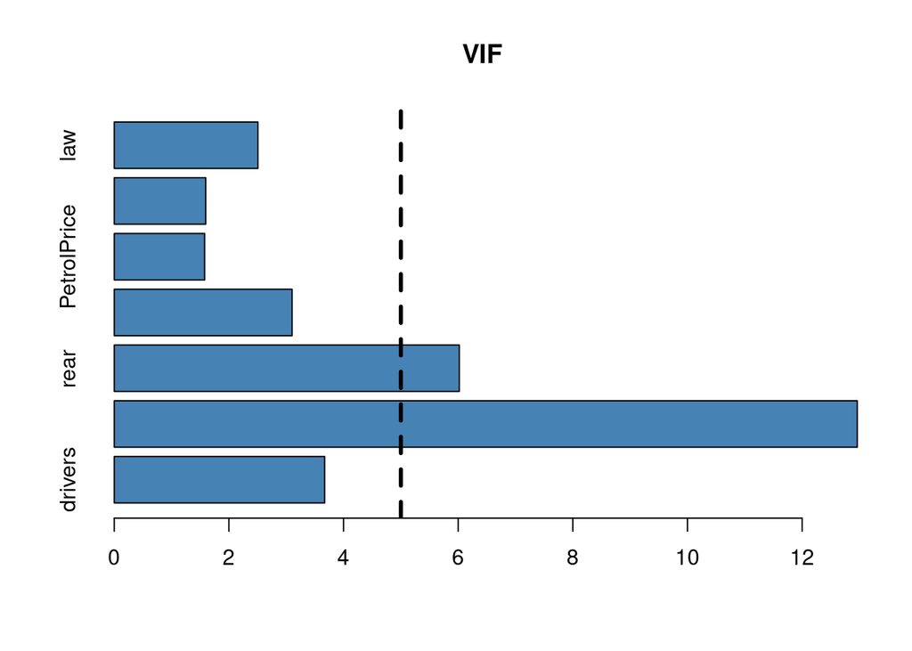

```r
barplot(v, main = "VIF", horiz = TRUE, col = "steelblue")
abline(v = 5, lwd = 3, lty = 2)
```

### Вилучаємо з моделі front та rear та превіряємо

```r
m <- lm(DriversKilled ~ drivers + kms + PetrolPrice + VanKilled + law, data = Seatbelts)
v <- vif(m)
v
```

```
##     drivers         kms PetrolPrice   VanKilled         law
##    1.631519    1.623866    1.372278    1.522746    1.499331
```

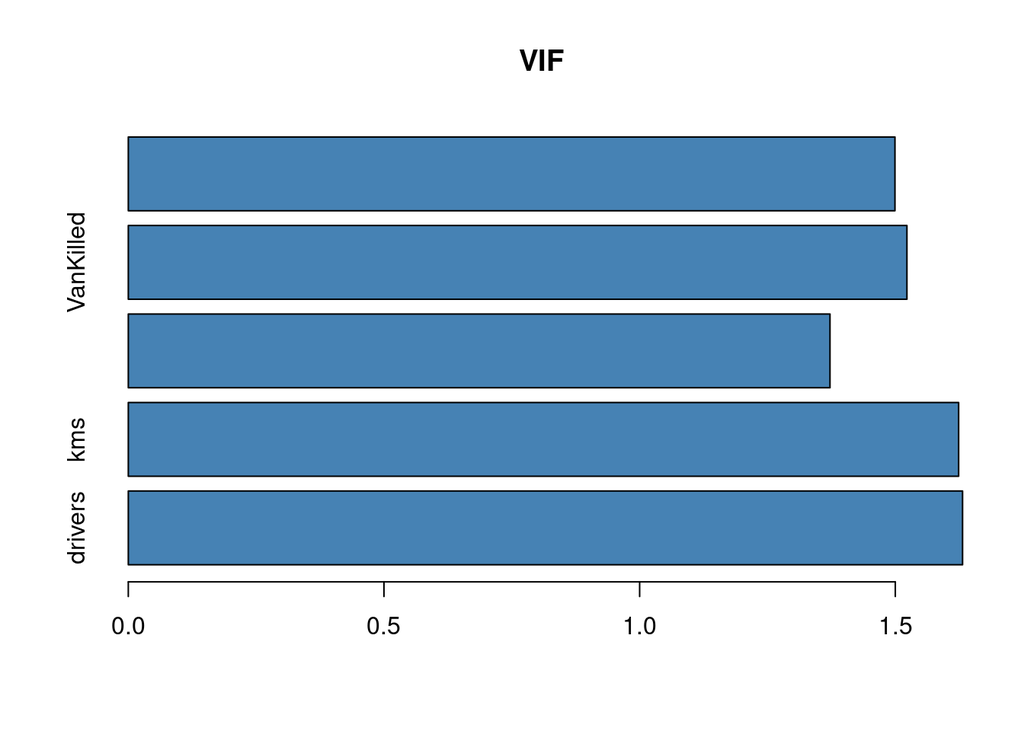

```r
barplot(v, main = "VIF", horiz = TRUE, col = "steelblue")
abline(v = 5, lwd = 3, lty = 2)
```

### Тепер нормально

## Оцінити модель лінійної, нелінійної, логістичної регресії

### Множинна лінійна

```r
m1 <- lm(DriversKilled ~ drivers + kms + PetrolPrice + VanKilled + law, data = Seatbelts)
summary(m1)
```

```
##
## Call:
## lm(formula = DriversKilled ~ drivers + kms + PetrolPrice + VanKilled +
##     law, data = Seatbelts)
##
## Residuals:
##     Min      1Q  Median      3Q     Max
## -29.453  -7.800  -0.604   7.749  34.402
##
## Coefficients:
##               Estimate Std. Error t value Pr(>|t|)
## (Intercept) -2.490e+01  1.283e+01  -1.941   0.0537 .
## drivers      8.255e-02  3.677e-03  22.450   <2e-16 ***
## kms          6.493e-04  3.616e-04   1.795   0.0742 .
## PetrolPrice -1.030e+01  8.022e+01  -0.128   0.8980
## VanKilled    6.530e-02  2.829e-01   0.231   0.8177
## law          4.651e+00  3.136e+00   1.483   0.1397
## ---
## Signif. codes:  0 '***' 0.001 '**' 0.01 '*' 0.05 '.' 0.1 ' ' 1
##
## Residual standard error: 11.52 on 186 degrees of freedom
## Multiple R-squared:  0.7993, Adjusted R-squared:  0.7939
## F-statistic: 148.1 on 5 and 186 DF,  p-value: < 2.2e-16
```

### Лінійна DriversKilled ~ drivers

```r
m2 <- lm(DriversKilled ~ drivers, data = Seatbelts)
summary(m2)
```

```
##
## Call:
## lm(formula = DriversKilled ~ drivers, data = Seatbelts)
##
## Residuals:
##     Min      1Q  Median      3Q     Max
## -28.140  -7.915  -0.323   7.624  33.894
##
## Coefficients:
##              Estimate Std. Error t value Pr(>|t|)
## (Intercept) -7.301120   4.938444  -1.478    0.141
## drivers      0.077892   0.002913  26.736   <2e-16 ***
## ---
## Signif. codes:  0 '***' 0.001 '**' 0.01 '*' 0.05 '.' 0.1 ' ' 1
##
## Residual standard error: 11.66 on 190 degrees of freedom
## Multiple R-squared:   0.79,  Adjusted R-squared:  0.7889
## F-statistic: 714.8 on 1 and 190 DF,  p-value: < 2.2e-16
```

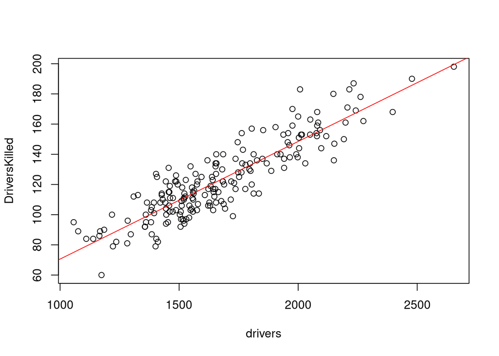

```r
plot(DriversKilled ~ drivers, xlab = 'drivers', ylab = 'DriversKilled', data = Seatbelts)
abline(m2, col = 'red')
```

#### Лінійна для DriversKilled ~ drivers, F-statistic: 714.8 on 1 and 190 DF, p-value: < 2.2e-16

### Лінійна drivers ~ front

```r
m3 <- lm(drivers ~ front, data = Seatbelts)
summary(m3)
```

```
##
## Call:
## lm(formula = drivers ~ front, data = Seatbelts)
##
## Residuals:
##     Min      1Q  Median      3Q     Max
## -379.64 -121.65  -17.49  109.10  487.92
##
## Coefficients:
##              Estimate Std. Error t value Pr(>|t|)
## (Intercept) 550.86223   60.40543   9.119   <2e-16 ***
## front         1.33710    0.07063  18.931   <2e-16 ***
## ---
## Signif. codes:  0 '***' 0.001 '**' 0.01 '*' 0.05 '.' 0.1 ' ' 1
##
## Residual standard error: 170.9 on 190 degrees of freedom
## Multiple R-squared:  0.6535, Adjusted R-squared:  0.6517
## F-statistic: 358.4 on 1 and 190 DF,  p-value: < 2.2e-16
```

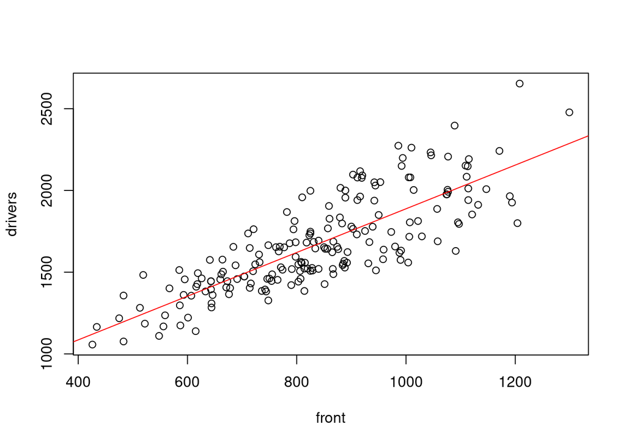

```r
plot(drivers ~ front, xlab = 'front', ylab = 'drivers', data = Seatbelts)
abline(m3, col = 'red')
```

#### Лінійна для drivers ~ front, F-statistic: 358.4 on 1 and 190 DF, p-value: < 2.2e-16

### Лінійна DriversKilled ~ front

```r
m4 <- lm(DriversKilled ~ front, data = Seatbelts)
summary(m4)
```

```
##
## Call:
## lm(formula = DriversKilled ~ front, data = Seatbelts)
##
## Residuals:
##     Min      1Q  Median      3Q     Max
## -42.800 -12.970  -2.114  14.626  43.104
##
## Coefficients:
##              Estimate Std. Error t value Pr(>|t|)
## (Intercept) 37.035763   6.362317   5.821 2.45e-08 ***
## front        0.102442   0.007439  13.771  < 2e-16 ***
## ---
## Signif. codes:  0 '***' 0.001 '**' 0.01 '*' 0.05 '.' 0.1 ' ' 1
##
## Residual standard error: 18 on 190 degrees of freedom
## Multiple R-squared:  0.4995, Adjusted R-squared:  0.4969
## F-statistic: 189.6 on 1 and 190 DF,  p-value: < 2.2e-16
```

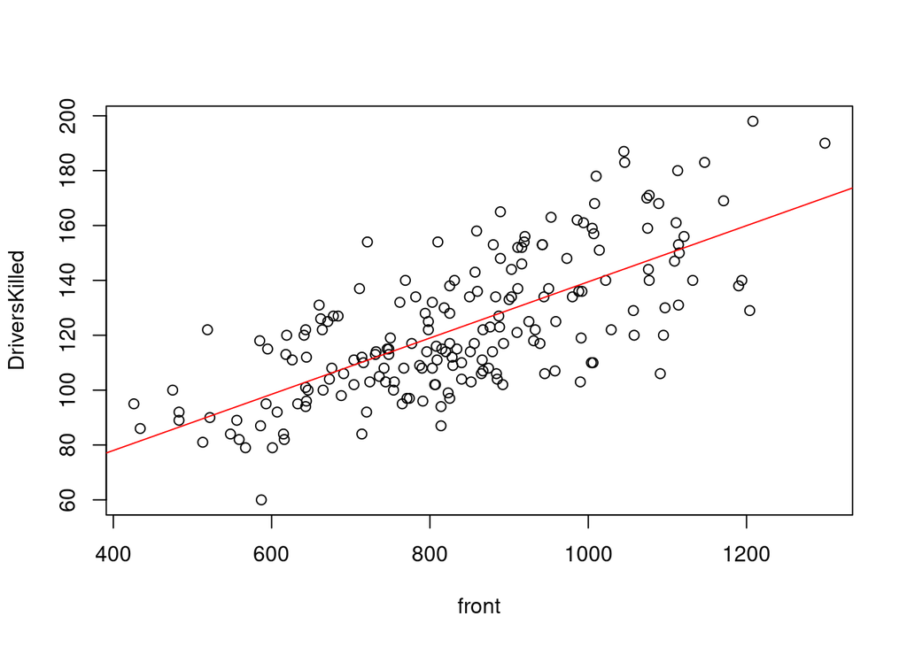

```r
plot(DriversKilled ~ front, xlab = 'front', ylab = 'DriversKilled', data = Seatbelts)
abline(m4, col = 'red')
```

#### Лінійна для DriversKilled ~ front, F-statistic: 189.6 on 1 and 190 DF, p-value: < 2.2e-16

### Лінійна та нелінійна VanKilled ~ kms

```r
m5 <- lm(VanKilled ~ kms, data = Seatbelts)
summary(m5)
```

```
##
## Call:
## lm(formula = VanKilled ~ kms, data = Seatbelts)
##
## Residuals:
##     Min      1Q  Median      3Q     Max
## -8.7980 -2.3571  0.2916  2.4467  7.3535
##
## Coefficients:
##               Estimate Std. Error t value Pr(>|t|)
## (Intercept)  1.830e+01  1.190e+00  15.383  < 2e-16 ***
## kms         -6.165e-04  7.787e-05  -7.917 1.98e-13 ***
## ---
## Signif. codes:  0 '***' 0.001 '**' 0.01 '*' 0.05 '.' 0.1 ' ' 1
##
## Residual standard error: 3.162 on 190 degrees of freedom
## Multiple R-squared:  0.248,  Adjusted R-squared:  0.2441
## F-statistic: 62.67 on 1 and 190 DF,  p-value: 1.98e-13
```

```r
m5_1 <- glm(VanKilled ~ kms, family = poisson, data = Seatbelts)
summary(m5_1)
```

```
##
## Call:
## glm(formula = VanKilled ~ kms, family = poisson, data = Seatbelts)
##
## Deviance Residuals:
##      Min        1Q    Median        3Q       Max
## -3.11981  -0.84559   0.09254   0.77727   2.36963
##
## Coefficients:
##               Estimate Std. Error z value Pr(>|z|)
## (Intercept)  3.210e+00  1.212e-01  26.481   <2e-16 ***
## kms         -6.843e-05  8.245e-06  -8.299   <2e-16 ***
## ---
## Signif. codes:  0 '***' 0.001 '**' 0.01 '*' 0.05 '.' 0.1 ' ' 1
##
## (Dispersion parameter for poisson family taken to be 1)
##
##     Null deviance: 291.16  on 191  degrees of freedom
## Residual deviance: 221.78  on 190  degrees of freedom
## AIC: 988
##
## Number of Fisher Scoring iterations: 4
```

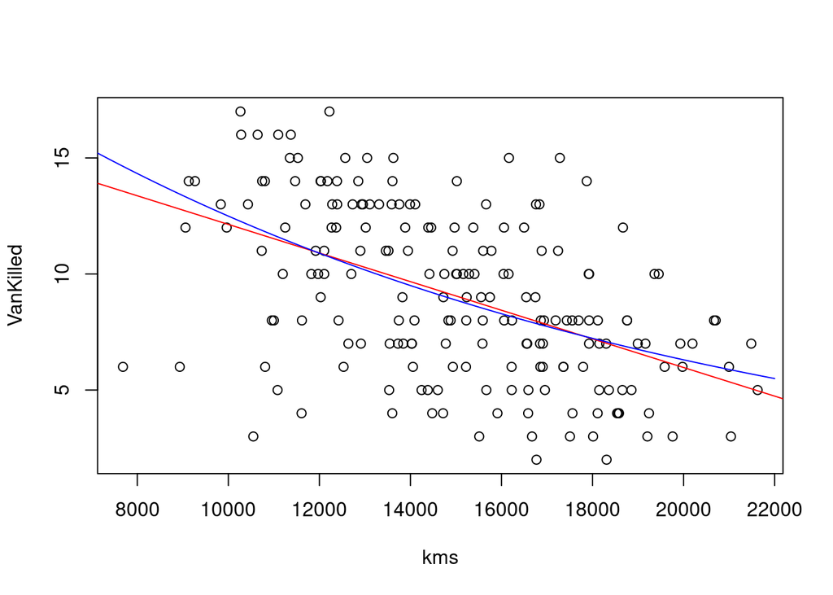

```r
p5 <- data.frame(kms = seq(from = 6000, to = 22000, by = 200))
pred5 <- predict(m5_1, newdata = p5, type = "response")

plot(VanKilled ~ kms, xlab = 'kms', ylab = 'VanKilled', data = Seatbelts)
abline(m5, col = 'red')
lines(p5$kms, pred5, col = 'blue')
```

#### Лінійна для VanKilled ~ kms, F-statistic: 62.67 on 1 and 190 DF, p-value: 1.98e-13

#### Нелінійна для VanKilled ~ kms, AIC: 988, не висока якість моделі

### Лінійна та логістична law ~ front

```r
m6 <- lm(law ~ front, data = Seatbelts)
summary(m6)
```

```
##
## Call:
## lm(formula = law ~ front, data = Seatbelts)
##
## Residuals:
##      Min       1Q   Median       3Q      Max
## -0.40238 -0.17362 -0.06878  0.11031  0.75867
##
## Coefficients:
##               Estimate Std. Error t value Pr(>|t|)
## (Intercept)  0.9953313  0.0953863  10.435   <2e-16 ***
## front       -0.0010458  0.0001115  -9.376   <2e-16 ***
## ---
## Signif. codes:  0 '***' 0.001 '**' 0.01 '*' 0.05 '.' 0.1 ' ' 1
##
## Residual standard error: 0.2699 on 190 degrees of freedom
## Multiple R-squared:  0.3163, Adjusted R-squared:  0.3127
## F-statistic: 87.92 on 1 and 190 DF,  p-value: < 2.2e-16
```

```r
m6_1 <- glm(law ~ front, family = binomial(link = "logit"), data = Seatbelts)
summary(m6_1)
```

```
##
## Call:
## glm(formula = law ~ front, family = binomial(link = "logit"),
##     data = Seatbelts)
##
## Deviance Residuals:
##      Min        1Q    Median        3Q       Max
## -1.74397  -0.12887  -0.03218  -0.00300   2.46672
##
## Coefficients:
##              Estimate Std. Error z value Pr(>|z|)
## (Intercept) 16.986446   3.890925   4.366 1.27e-05 ***
## front       -0.027711   0.006092  -4.549 5.40e-06 ***
## ---
## Signif. codes:  0 '***' 0.001 '**' 0.01 '*' 0.05 '.' 0.1 ' ' 1
##
## (Dispersion parameter for binomial family taken to be 1)
##
##     Null deviance: 140.740  on 191  degrees of freedom
## Residual deviance:  51.215  on 190  degrees of freedom
## AIC: 55.215
##
## Number of Fisher Scoring iterations: 8
```

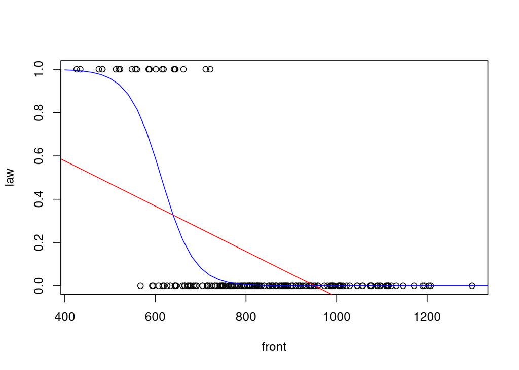

```r
p6 <- data.frame(front = seq(from = 400, to = 1600, by = 20))
pred6 <- predict(m6_1, newdata = p6, type = "response")

plot(law ~ front, xlab = 'front', ylab = 'law', data = Seatbelts)
abline(m6, col = 'red')
lines(p6$front, pred6, col = 'blue')
```

#### Лінійна для law ~ front, F-statistic: 87.92 on 1 and 190 DF, p-value: < 2.2e-16

#### Логістична для law ~ front, AIC: 55.215, досить висока якість